# Reproducible Research: Peer Assessment 1

## Loading and preprocessing the data

The data in activity.csv file is loaded into r data frame.

```r
   #load the data from file 'activity.csv'
   activity <- read.csv('activity.csv')
```

Rows with no measurements are then removed.

```r
   #remove the rows with no measurements i.e. NA
   activity.clean <- na.omit(activity)
```

Out of total 17568 rows in the data file, 15264 rows were found to be complete (i.e. having some value other than NA).

## What is mean total number of steps taken per day?

Total number of steps taken per day is calculated as follows

```r
   activity.daily <- aggregate(steps~date,activity,sum)
```

Histogram of total steps taken per day

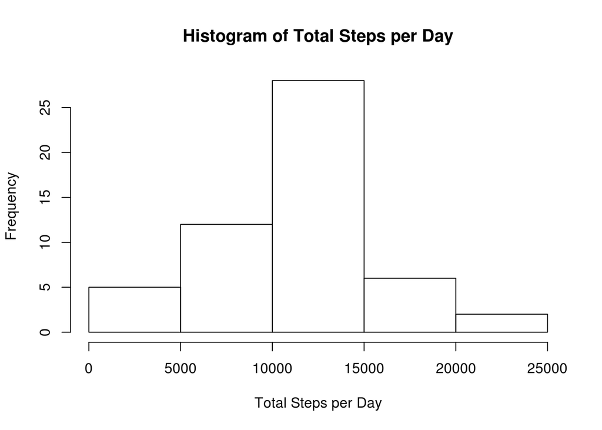

```r
   hist(activity.daily$steps,xlab = 'Total Steps per Day',main = 'Histogram of Total Steps per Day')
```

Mean steps taken per day are

```r
   mean(activity.daily$steps)
```

```
## [1] 10766.19
```

Median steps taken per day are

```r
   median(activity.daily$steps)
```

```
## [1] 10765
```

## What is the average daily activity pattern?

Average steps taken within each time interval (across all days)

```r
    activity.time <- aggregate(steps~interval,activity.clean,mean)
```

Time series plot

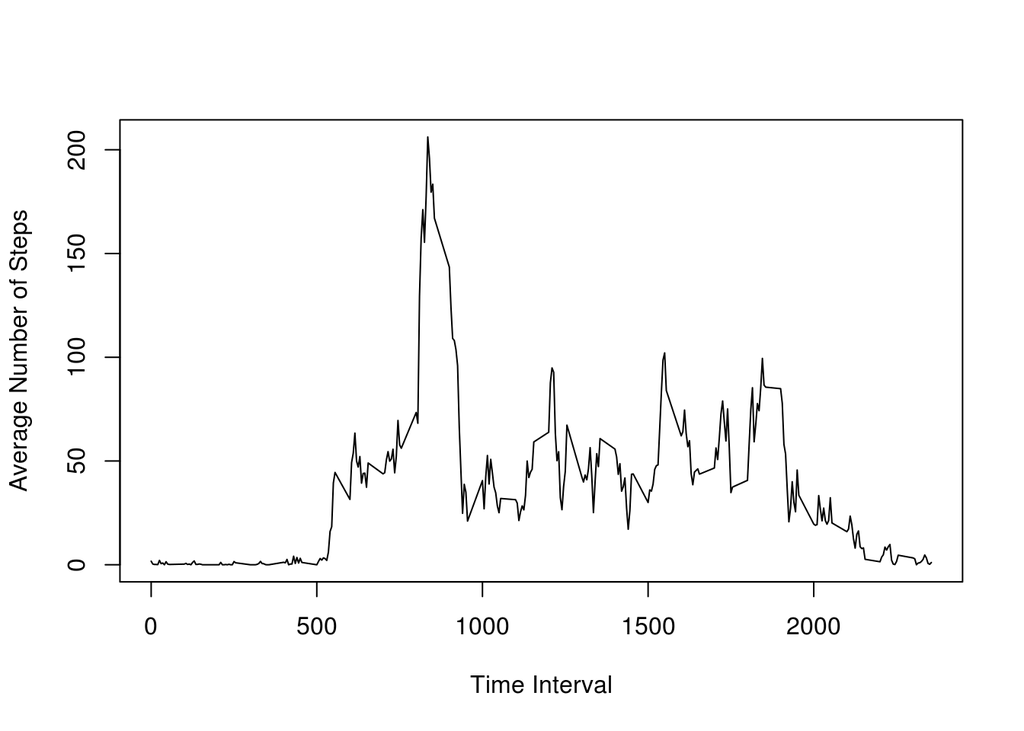

```r
   plot(x=activity.time$interval,y=activity.time$steps,type = 'l',xlab = 'Time Interval',ylab = 'Average Number of Steps')
```

Time interval for which maximum steps are taken

```r
   activity.max <- activity.time[activity.time$steps==max(activity.time$steps),]
   activity.max
```

```
##     interval    steps
## 104      835 206.1698
```

## Imputing missing values

Total number of missing values (i.e. rows with NA) are

```r
   dim(activity)[1] - dim(activity.clean)[1]
```

```
## [1] 2304
```

Impute missing values using the interval average steps

```r
   activity.imputed <- activity
   activity.imputed <- transform(activity.imputed,
                                 steps=ifelse(is.na(steps),
                                              activity.time[activity.time$interval %in% interval,'steps'],
                                              steps))
```

Total number of steps taken per day is calculated as follows

```r
   activity.imputed.daily <- aggregate(steps~date,activity.imputed,sum)
```

Histogram of total steps taken per day

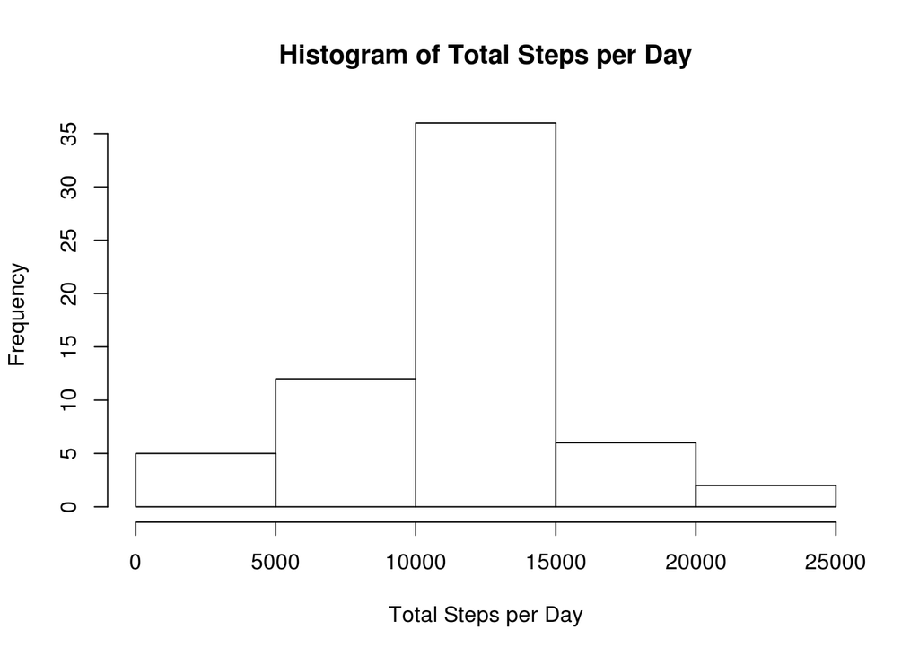

```r
   hist(activity.imputed.daily$steps,xlab = 'Total Steps per Day',main = 'Histogram of Total Steps per Day')
```

Mean steps taken per day are

```r
   mean(activity.imputed.daily$steps)
```

```
## [1] 10766.19
```

Median steps taken per day are

```r
   median(activity.imputed.daily$steps)
```

```
## [1] 10766.19
```

With imputation, median has converged to mean i.e. mean and median are now same.

## Are there differences in activity patterns between weekdays and weekends?

Add new factor variable for identification of weekday and weekend

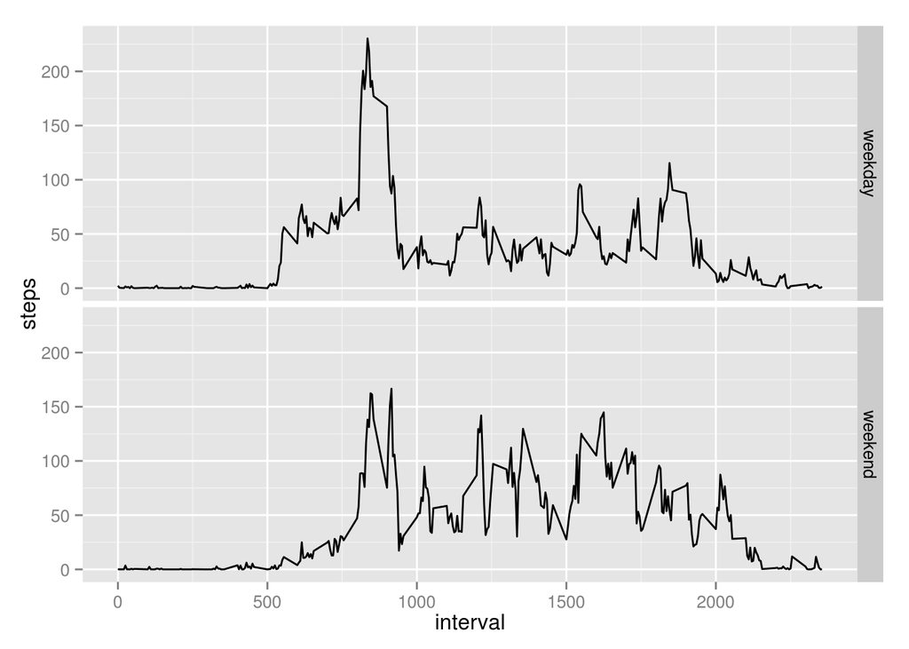

```r
   activity.imputed$day <- weekdays(as.Date(activity.imputed$date),abbreviate = T)
   activity.imputed$daytype <- ifelse(activity.imputed$day %in% c('Sat','Sun'),'weekend','weekday')
   activity.imputed$daytype <- as.factor(activity.imputed$daytype)
   activity.imputed.pattern <- aggregate(steps ~ daytype * interval, activity.imputed, mean)


   library(ggplot2)
   qplot(interval,steps, data = activity.imputed.pattern, facets = daytype~., geom='path')
```